# Homework 1: Transforming data

Due 2015-02-05

Topics covered in this homework include:

- dplyr and the five verbs
- working with factors
- third normal form
- tidy data
1. **Please calculate 2+2 in the space below.**

```r
2+2
```

```
## [1] 4
```

### A robustness check

In lab, we calculated the rate of red cards for players of different skin tone. Now, we are going to see how robust our conclusions were to some of the choices that we made in the analysis. In particular, it is important to know that in soccer there are actually two ways to get a red card: a direct red card and getting two yellow cards (which equals one red card).

2. **Create a table like the one were made in lab where the outcome of interest is rate of direct red cards.**

```r
soccer.data %>%
  filter(!(is.na(rater1) | is.na(rater2))) %>%
  mutate(skin.color = (rater1 + rater2) / 2) %>%
  group_by(skin.color) %>%
  summarise(total.reds = sum(red.cards), total.games = sum(games)) %>%
  mutate(red.rate=total.reds / total.games)
```

```
## Source: local data frame [9 x 4]
##
##   skin.color total.reds total.games    red.rate
## 1      0.000        381       99636 0.003823919
## 2      0.125        198       54137 0.003657388
## 3      0.250        535      120574 0.004437109
## 4      0.375         83       15936 0.005208333
## 5      0.500        125       25415 0.004918355
## 6      0.625         15        6493 0.002310180
## 7      0.750        100       20800 0.004807692
## 8      0.875         41        8134 0.005040570
## 9      1.000        111       21942 0.005058791
```

3. **Imagine that you submitted the table above in a paper (Of course, in a real paper you would create a graph, but we have not learned `ggplot2` yet.) Create a table like the one above but where the outcome of interest is rate of all forms of red cards (direct red cards + two yellow cards). The column red.cards is direct red cards and the column yellow.reds is the red cards that result from two yellow cards.**

```r
soccer.data %>%
  filter(!(is.na(rater1) | is.na(rater2))) %>%
  mutate(skin.color = (rater1 + rater2) / 2) %>%
  mutate(all.reds = red.cards + yellow.reds) %>%
  group_by(skin.color) %>%
  summarise(total.all.reds = sum(all.reds), total.games = sum(games)) %>%
  mutate(red.rate=total.all.reds / total.games)
```

```
## Source: local data frame [9 x 4]
##
##   skin.color total.all.reds total.games    red.rate
## 1      0.000            761       99636 0.007637802
## 2      0.125            393       54137 0.007259361
## 3      0.250           1039      120574 0.008617115
## 4      0.375            174       15936 0.010918675
## 5      0.500            221       25415 0.008695652
## 6      0.625             38        6493 0.005852456
## 7      0.750            179       20800 0.008605769
## 8      0.875             73        8134 0.008974674
## 9      1.000            214       21942 0.009752985
```

4. In words, compare your answers in questions 2 and 3. Do this choice make a difference?

```
It does not seem to make a difference if you use only direct red cards or all types of red cards.
```

### Looking at subsets of the data, by country

Imagine that you presented these results at ASA, and an audience member speculated the relationship between skin tone and red cards would be different in the different soccer leagues.

5. **Create a table that shows, for each league, the rate of red cards by skin color. In this case, please use direct red cards (red.cards) as you outcome.**

```r
soccer.data %>%
  filter(!(is.na(rater1) | is.na(rater2))) %>%
  mutate(skin.color = (rater1 + rater2) / 2) %>%
  group_by(league.country, skin.color) %>%
  summarise(total.reds = sum(red.cards), total.games = sum(games)) %>%
  mutate(red.rate=total.reds / total.games)
```

```
## Source: local data frame [36 x 5]
## Groups: league.country
##
##    league.country skin.color total.reds total.games     red.rate
## 1         England      0.000        118       30788 0.0038326621
## 2         England      0.125         53       17736 0.0029882724
## 3         England      0.250        101       29823 0.0033866479
## 4         England      0.375          3        2058 0.0014577259
## 5         England      0.500         53       10849 0.0048852429
## 6         England      0.625          2        2355 0.0008492569
## 7         England      0.750         40        7032 0.0056882821
## 8         England      0.875         16        3188 0.0050188206
## 9         England      1.000         41       10384 0.0039483821
## 10         France      0.000         52        9696 0.0053630363
## ..            ...        ...        ...         ...          ...
```

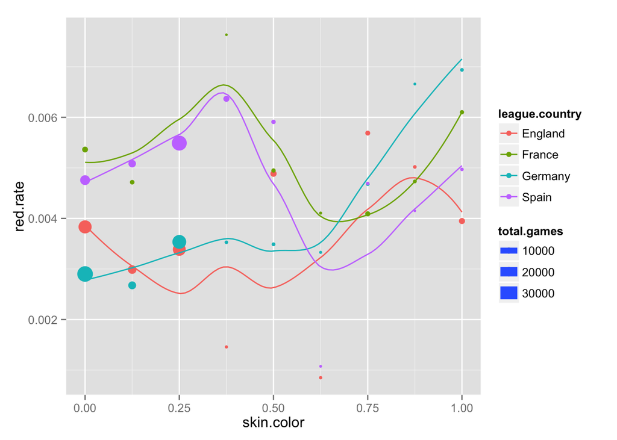

```r
# it is really hard to see much in that table, we can also make a graph
library(ggplot2)
soccer.data %>%
  filter(!(is.na(rater1) | is.na(rater2))) %>%
  mutate(skin.color = (rater1 + rater2) / 2) %>%
  group_by(league.country, skin.color) %>%
  summarise(total.reds = sum(red.cards), total.games = sum(games)) %>%
  mutate(red.rate=total.reds / total.games) %>%
  ggplot( aes(x=skin.color, y=red.rate, color=league.country, size=total.games)) + geom_point() + stat_smooth(method = "loess", se=FALSE)
```

6. **In words, what would you conclude from your response to 5?**

[output not shown]